# Regresión Bayesiana. Modelo conjugado

Victor Gallego y Roi Naveiro

20/05/2019

**Cargamos los paquetes**

```r
library(ggplot2)
```

Este ejercicio pretende arrojar algo de intuición sobre la regresión Bayesiana.

# El modelo

Trabajaremos con una sola covariable para poder visualizar gráficamente los resultados. Además, asumiremos la precisión conocida. En concreto

$$p(y \vert w,x) = \mathcal{N} (w_0 + w_1x, \sigma^2)$$

Donde los valores reales de los parámetros son $w_0 = -0.3$, $w_1 = 0.5$ y $\sigma = 0.2$. Además, muestrearemos $x$ de una uniforme entre -1 y 1.

Escribe dos funciones, `make.X` y `make.Y` que generen los datos.

```r
make.X <- function(n) {
  runif(n,-1,1)
}

w0 <- -0.3 # valores reales de los pesos
w1 <-  0.5

sigma <- 0.2
beta  <- 1/sigma^2  # precision

make.Y <- function(xs) {
  w0 + w1*xs + rnorm(length(xs),0,sigma)
}
```

# Cálculo del posterior

Gracias a la conjugación, la distribución a posteriori será también Gaussiana.

$$\begin{equation}
p(w \vert \boldsymbol{t}, X) = \mathcal{N}(w \vert m_N, S_N)
\end{equation}$$

Donde

$$\begin{eqnarray*}
m_N &=& S_N(S_0^{-1} m_0 + \beta \Phi^\top \boldsymbol{t}) \\
S_N^{-1} &=& S_0^{-1} + \beta \Phi^\top \Phi
\end{eqnarray*}$$

La información se puede actualizar secuencialmente, a medida que llegan datos. Escribe una función que, dados unos nuevos datos $X,Y$, y un prior parametrizado por $m_{old}$, $S_{old}$, calcule el posterior. Utiliza la función identidad como base

```r
compute_posterior <- function(X, Y, m_old, S_old, phi= c(one, id)) {
  # crea la matriz de diseño
  Phi <- as.matrix(X)
  Phi = cbind(rep(1, length(Phi)), Phi)

  S_new <- solve(solve(S_old) + beta * t(Phi) %*% Phi)
  m_new <- S_new %*% (solve(S_old) %*% m_old + beta * t(Phi) %*% Y)

  list(m=m_new, S=S_new)
}
```

# Usando un prior concreto

Vamos a empezar con un prior de media 0, y con matriz de covarianza diagonal

```r
alpha <- 2.0
m_0 <- c(0,0)
S_0 <- alpha*diag(2)
```

Ahora, construye 3 puntos y actualiza el posterior

```r
X <- make.X(3) # 3 puntos
Y <- make.Y(X)

posterior_1 <- compute_posterior(X, Y, m_0, S_0)
posterior_1$m
```

```
##             [,1]
## [1,] -0.05420911
## [2,]  0.98623551
```

Representa gráficamente los puntos obtenidos y la recta de regresión dada por la media de la distribución a posteriori

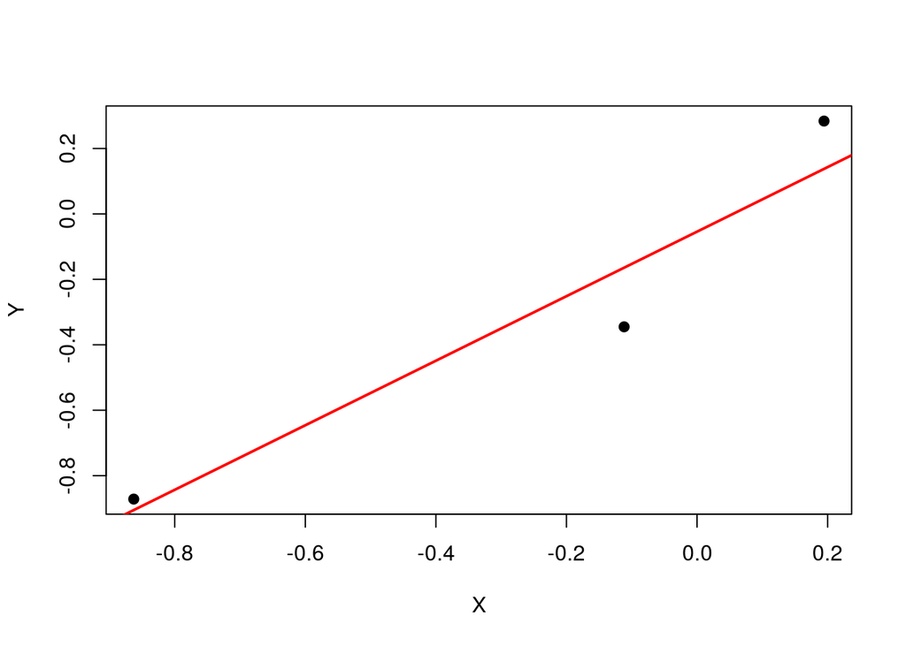

```r
plot(X, Y, pch=19, col="black")
abline(posterior_1$m, col="red", lwd=2)
```

Utilizando la siguiente función, representa secuencialmente la distribución a posteriori, a medida que vas añadiendo más puntos.

```r
library(mvtnorm)
library(ggplot2)
draw_bivariate <- function(m, S, lims=c(-1.5,1.5)) {

  data.grid <- expand.grid(s.1 = seq(lims[1], lims[2], length.out=200), s.2 = seq(lims[1], lims[2], length.out=200))
  #
  q.samp <- cbind(data.grid, prob = mvtnorm::dmvnorm(data.grid, mean = m,
  sigma = S))
  #
  ggplot() +
    geom_contour(data=q.samp,aes(x=s.1,y=s.2,z=prob)) + xlim(lims[1], lims[2]) + ylim(lims[1], lims[2]) + geom_hline(yintercept=w1, linetype="dashed", color = "red") + geom_vline(xintercept=w0, linetype="dashed", color = "red") + xlab("w0") + ylab("w1")
}
```

Primero el prior

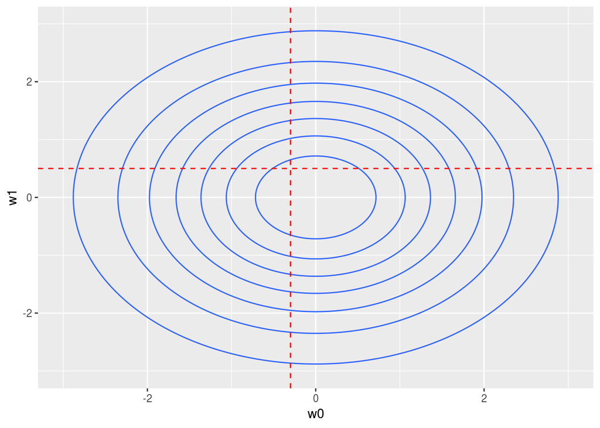

```r
draw_bivariate(m_0, S_0, lims=c(-3,3))
```

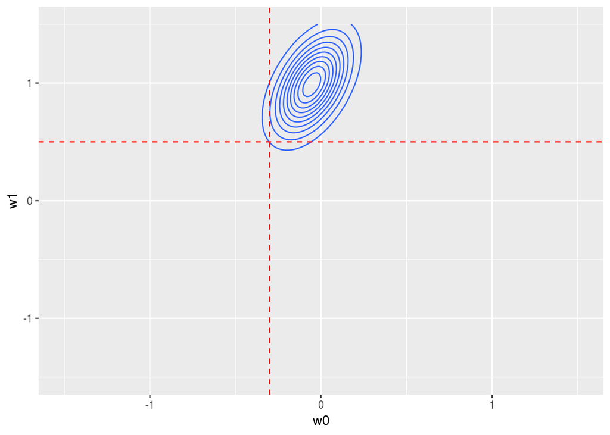

```r
draw_bivariate(posterior_1$m, posterior_1$S)
```

Añade otros 10 puntos y representa de nuevo el posterior.

```r
X_new <- make.X(10)
Y_new <- make.Y(X_new)

posterior_2 <- compute_posterior(X_new,  Y_new, posterior_1$m, posterior_1$S)
posterior_2$m
```

```
##            [,1]
## [1,] -0.3075621
## [2,]  0.5922878
```

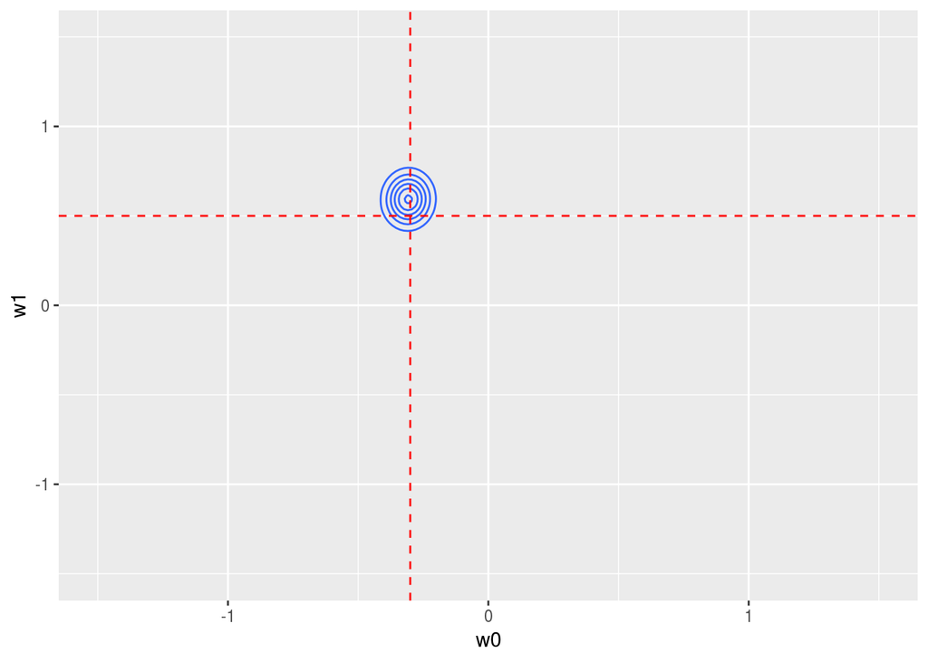

```r
draw_bivariate(posterior_2$m, posterior_2$S)
```

# Distribución predictiva

En general, estamos interesados en la distribución predictiva. En este caso, esta distribución tiene forma analítica cerrada: es fácil probrar que $p(t \vert \boldsymbol{t},\alpha, \beta) = \mathcal{N}(t \vert m_N^\top \phi(x), \sigma_N^2(x))$, con

$$\begin{equation}
\sigma_N^2(x) = \frac{1}{\beta} + \phi(x)^\top S_N \phi(x)
\end{equation}$$

Escribe una función que, dada una nueva observación y los parámetros del posterior, devuelva los media de la distribución preditiva y el intervalo del 95% de probabilidad.

```r
get_predictive_vals <- function(x, m_N, S_N) {
  phi <- as.matrix(x)
  phi = t( cbind(rep(1, length(phi)), phi) )
  mean_pred <- t(m_N) %*% phi
  sd_pred  <- sqrt(1/beta + t(phi) %*% S_N %*% phi)

  c(mean_pred, mean_pred-2*sd_pred, mean_pred+2*sd_pred)
}
```

Utilizaremos esta función auxiliar para representar los resultados gráficamente.

```r
draw_predictive <- function(xs, m_N, S_N, phi) {
  vs <- rep(NA, length(xs))
  ys <- data.frame(means=vs, p2.5=vs, p97.5=vs)

  for (i in 1:length(xs)) {
    ys[i,] <- get_predictive_vals(xs[i],m_N, S_N)
  }


  lines(xs, ys[,1], col="red", lwd=2)
  lines(xs, ys[,2], col="red", lty="dashed")
  lines(xs, ys[,3], col="red", lty="dashed")
}
```

Veamos algún ejemplo concreto. En este bloque tendrás que:

1. Definir el prior isotrópico centrado en cero, con $\alpha = 2$.
2. Crear 2 puntos $(X,Y)$ con el modelo que utilizamos.
3. Calcular la distribuciión a posteriori.
4. Calcular media e intervalo del 95% de probabilidad de la predictiva en una red de 50 valores de x entre -1 y 1.

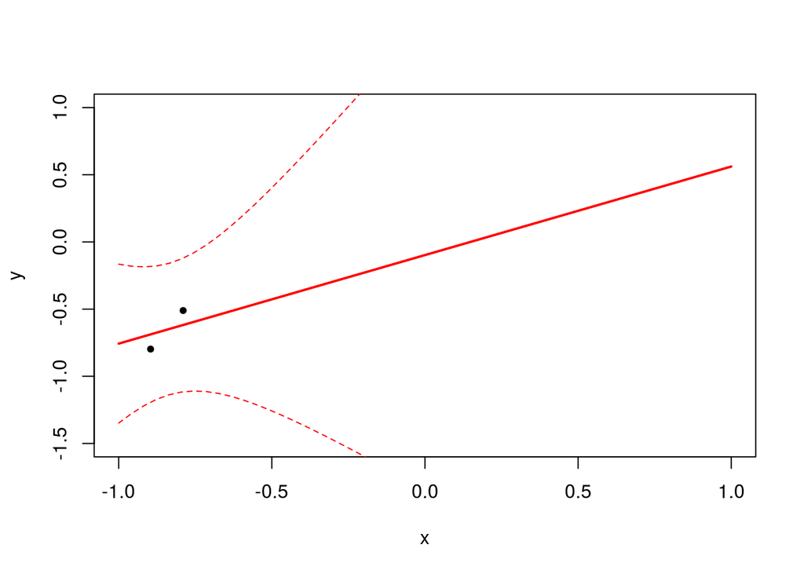

```r
X <- make.X(2) # Crea 2 puntos
Y <- make.Y(X)

alpha <- 2.0
m_0 <- c(0,0)
S_0 <- alpha*diag(2)

posterior_1 <- compute_posterior(X, Y, m_0, S_0)
m_N <- posterior_1$m
S_N <- posterior_1$S

plot(X, Y, pch=20, ylim=c(-1.5,1), xlim=c(-1,1), ylab="y", xlab="x")
xs <- seq(-1,1,len=50)
draw_predictive(xs, m_N, S_N)
```

¿Qué sucede con la varianza en puntos alejados de los puntos conocidos?

Por último añade 10 puntos, actualiza el posterior y representa de nuevo la predictiva. ¿Añadiendo más puntos seríamos capaces de reducir infinitamente los intervalos de probabilidad?

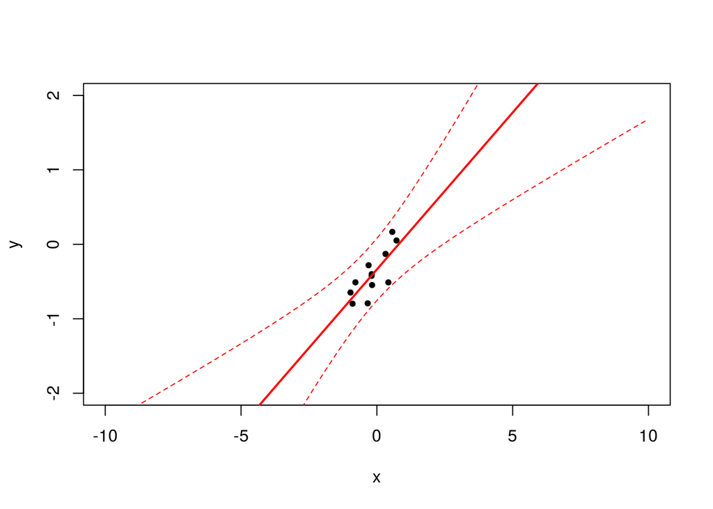

```r
X_new <- make.X(10)
Y_new <- make.Y(X_new)

posterior_2 <- compute_posterior(X_new, Y_new, posterior_1$m, posterior_1$S)
m_N <- posterior_2$m
S_N <- posterior_2$S

xs <- seq(-10,10,len=500)
plot(c(X,X_new), c(Y,Y_new), pch=20, ylim=c(-2,2), xlim=c(-10,10), ylab="y", xlab="x")
draw_predictive(xs, m_N, S_N)
```